# Mapeamento associativo genômico amplo (GWAS) com espécie diploide

Tutorial seguindo o exemplo e recomendações do GAPIT

Dra. Luciana de Sousa Lopes e Ms. Cristian Cordeiro de Jesus

19/12/2025

# 1 Introdução ao conceito do mapeamento por associação do genoma amplo (GWAS - *Genome wide association study*)

O termo Quantitative Trait Locci (QTL) é utilizado para classificar regiões genômicas que controlam a expressão de caracteres quantitativos e que, normalmente, recebem forte influência do ambiente. Com o surgimento dos marcadores moleculares, foi possível mapear estes loci a partir de duas abordagens que tem o desequilíbrio de ligação (DL - *Linkage disequilibrium*) como base: o mapeamento por ligação e o mapeamento por associação. O primeiro, também conhecido como mapeamento de QTL utiliza cruzamentos controlados a partir de parentais com loci constrastantes, podendo utilizar populações F1 como no caso espécies com alta segregação como a cana-de-açúcar ou que possuem longo ciclo de vida, populações F2 (Painel a) como é utilizado para a maioria das culturas agrícolas, retrocruzamentos, linhagens endogâmicas recombinantes (RILS - *Recombinant Inbred Lines*), enquanto que no mapeamento associativo, podem ser utilizadas populações naturais, coleções de germoplasma e um conjunto de materiais-elite, sendo comumente denominados como painéis associativos. Outro ponto a se considerar é que o mapeamento por ligação possui algumas limitações, como, por exemplo, variabilidade genética limitada, estando restrita apenas a variabilidade entre os parentais e também a necessidade de formar uma população *de novo* que pode requerir mais gastos e demandar maior tempo. Para vencer essas limitações, o mapeamento por associação surge como uma abordagem interessante, porque por maior variabilidade genética e considerar mais eventos de recombinação, o que gera um mapeamento com melhor resolução (Painel b).

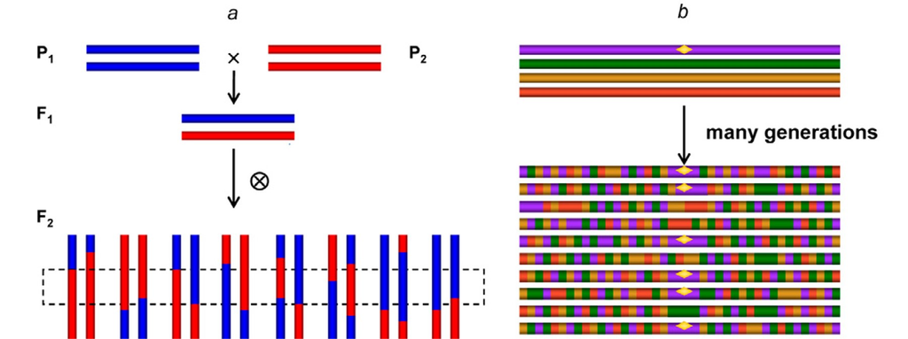

Fonte: Zhu et al. (2008)

Ao trabalhar com mapeamento associativo, devemos levar em consideração alguns fatores que podem afetar a resolução e a acurácia do mapeamento:

- Tamanho e tipo populacional
- Estrutura populacional e grau de parentesco
- Decaimento do desequilíbrio de ligação

Ao longo do script comentamos um pouco sobre análisar e interpretar alguns resultados em relação a esses fatores.

# 2 Preparo dos pacotes

## 2.1 Leitura dos pacotes necessários

```r
library(multtest) # Bioconductor (esse pacote não está no CRAN)
library(gplots)
library(genetics)
library(ape)
library(EMMREML)
library(compiler)
library(scatterplot3d)
library(qqman)
library(ggplot2)
library(bigmemory)
library(dplyr)
library(tidyverse)
library(FactoMineR)
library(factoextra)
```

## 2.2 Leitura das funções do GAPIT

O arquivo “gapit_functions.txt” baixa as funções do GAPIT para serem rodadas no R. Esta é uma alternativa para quando o GAPIT não é instalado no CRAN, mas sim baixado manualmente. O “emma.txt” implementa funções do GAPIT. A função “source” é usada para ler um arquivo externo, interpretar o código e carrega-la na sessão atual.

```r
source('gapit_functions.txt')
source('emma.txt')
```

# 3 Leitura dos dados

## 3.1 Dados fenótipicos

O myY é a codificação para fenótipo, como recomendação do manual do GAPIT. O uso read.table evita erros quando usado no gapit. A coluna Taxa são as unidades taxonômicas ordinárias como o nome da linhagem, nome do acesso do banco de germoplasma, genótipo, clones e variedades. É importante evitar o uso de acentos, cedilhas e espaços.

- EarTH = altura de espiga
- dpoll = dias para polinização
- EarDia = diâmetro de espiga

```r
myY <- read.table("mdp_traits.txt", header = TRUE)
myY
```

| Taxa | EarHT | dpoll | EarDia |
| --- | --- | --- | --- |
| 811 | 59.50 | NaN | NaN |
| 4226 | 65.50 | 59.5 | 32.21933 |
| 4722 | 81.13 | 71.5 | 32.42100 |
| 33-16 | 64.75 | 64.5 | NaN |
| 38-11 | 92.25 | 68.5 | 37.89700 |
| A188 | 27.50 | 62.0 | 31.41900 |
| A214N | 65.00 | 69.0 | 32.00600 |
| A239 | 47.88 | 61.0 | 36.06400 |
| A272 | 35.63 | 70.0 | NaN |
| A441-5 | 53.50 | 67.5 | 35.00800 |

[output cut: 291 more lines]

## 3.2 Dados genotípicos com informações

Observar que o argumento *header* deve ser *FALSE* apesar da linha de cabeçalho estar presente no arquivo *HAPMAP* (nesse arquivo está contido o nome do SNP, os alelos, a posição, em que fita, qual assembly foi usado para identificar esses SNPs). A linha do cabeçalho foi lida na tabela, se colocar o header = TRUE o script não funciona, o R tem dificuldades em ler arquivos largos, porque será testada coluna por coluna. Os SNPs estão nas linhas. Quando utilizamos o arquivo *HAPMAP* não precisamos utilizar os arquivos que contém os dados númericos e outro arquivo que contém as posições, alteradno um pouco a conformação do script.

```r
myG <- read.table("mdp_genotype_test.hmp.txt", header = FALSE)
head(myG)
```

|  | V1 | V2 | V3 | V4 | V5 | V6 | V7 | V8 | V9 | V10 | V11 | V12 | V13 | V14 | V15 | V16 | V17 | V18 | V19 | V20 | V21 | V22 | V23 | V24 | V25 | V26 | V27 | V28 | V29 | … |
| --- | --- | --- | --- | --- | --- | --- | --- | --- | --- | --- | --- | --- | --- | --- | --- | --- | --- | --- | --- | --- | --- | --- | --- | --- | --- | --- | --- | --- | --- | --- |
| 1 | rs | alleles | chrom | pos | strand | assembly | center | protLSID | assayLSID | panel | QCcode | 33-16 | 38-11 | 4226 | 4722 | A188 | A214N | A239 | A272 | A441-5 | A554 | A556 | A6 | A619 | A632 | A634 | A635 | A641 | A654 | … |
| 2 | PZB00859.1 | A/C | 1 | 157104 | + | AGPv1 | Panzea | NA | NA | maize282 | NA | CC | CC | CC | CC | AA | CC | AA | AA | CC | CC | CC | AA | CC | CC | CC | CC | AA | NN | … |
| 3 | PZA01271.1 | C/G | 1 | 1947984 | + | AGPv1 | Panzea | NA | NA | maize282 | NA | CC | GG | CC | GG | CC | CC | CC | CC | CC | GG | CC | CC | GG | CC | CC | CC | CC | GG | … |
| 4 | PZA03613.2 | G/T | 1 | 2914066 | + | AGPv1 | Panzea | NA | NA | maize282 | NA | GG | GG | GG | GG | GG | TT | TT | TT | GG | TT | GG | TT | GG | TT | TT | TT | TT | TT | … |
| 5 | PZA03613.1 | A/T | 1 | 2914171 | + | AGPv1 | Panzea | NA | NA | maize282 | NA | TT | TT | TT | TT | TT | AA | TT | TT | TT | TT | TT | TT | TT | AA | AA | AA | TT | TT | … |
| 6 | PZA03614.2 | A/G | 1 | 2915078 | + | AGPv1 | Panzea | NA | NA | maize282 | NA | GG | GG | GG | GG | GG | GG | AA | AA | GG | AA | GG | AA | GG | GG | GG | GG | AA | AA | … |

# 4 Avaliando a estrutura populacional

## 4.1 Lendo o arquivo que contém as informações dos marcadores SNPs em formato númerico

O formato númerico se refere a 0, 1 e 2, que são referentes ao número de cópias dos alelos. * O comando head(geno) mostra as seis primeiras linhas do arquivo, sem a necessidade de abrir o arquivo inteiro, porque pode ser um arquivo muito grande. *O comando dim(geno) conta a quantidade de linhas e colunas.* O comando geno <- geno[ , -1] exclui a primeira coluna que é chamada de “taxa”

```r
geno <- read.table("mdp_numeric.txt",
                   header = TRUE,
                   stringsAsFactors = FALSE)
head(geno)
```

|  | taxa | PZB00859.1 | PZA01271.1 | PZA03613.2 | PZA03613.1 | PZA03614.2 | PZA03614.1 | PZA00258.3 | PZA02962.13 | PZA02962.14 | PZA00599.25 | PZA02129.1 | PZA00393.1 | PZA02869.8 | PZA02869.4 | PZA02869.2 | PZA02032.1 | zagl1.5 | zagl1.2 | zagl1.6 | PZD00081.2 | zagl1.1 | PZB00919.1 | PZB00919.2 | PHM2244.142 | PZA03093.10 | PZA00181.5 | PZA00181.2 | PZA00528.1 | … |
| --- | --- | --- | --- | --- | --- | --- | --- | --- | --- | --- | --- | --- | --- | --- | --- | --- | --- | --- | --- | --- | --- | --- | --- | --- | --- | --- | --- | --- | --- | --- |
| 1 | 33-16 | 2 | 0 | 0 | 2 | 2 | 2 | 2 | 2 | 0 | 0 | 2 | 2 | 0 | 0 | 1 | 0 | 0 | 2 | 2 | 0 | 0 | 2 | 2 | 1 | 0 | 1 | 0 | 0 | … |
| 2 | 38-11 | 2 | 2 | 0 | 2 | 2 | 2 | 0 | 2 | 0 | 2 | 0 | 2 | 2 | 0 | 2 | 2 | 0 | 2 | 2 | 0 | 0 | 2 | 2 | 2 | 2 | 2 | 2 | 2 | … |
| 3 | 4226 | 2 | 0 | 0 | 2 | 2 | 2 | 0 | 2 | 0 | 0 | 0 | 2 | 0 | 0 | 2 | 0 | 0 | 2 | 2 | 0 | 0 | 2 | 2 | 2 | 2 | 0 | 0 | 0 | … |
| 4 | 4722 | 2 | 2 | 0 | 2 | 2 | 2 | 1 | 2 | 0 | 2 | 0 | 0 | 1 | 1 | 0 | 0 | 0 | 2 | 2 | 0 | 0 | 2 | 2 | 2 | 2 | 2 | 2 | 2 | … |
| 5 | A188 | 0 | 0 | 0 | 2 | 2 | 2 | 0 | 2 | 0 | 2 | 0 | 2 | 0 | 2 | 2 | 0 | 0 | 2 | 2 | 0 | 0 | 0 | 2 | 2 | 2 | 2 | 2 | 1 | … |
| 6 | A214N | 2 | 0 | 2 | 0 | 2 | 0 | 0 | 2 | 0 | 2 | 2 | 2 | 0 | 0 | 2 | 2 | 0 | 2 | 2 | 0 | 0 | 2 | 2 | 2 | 0 | 2 | 2 | 2 | … |

```r
dim(geno)
```

```
## [1]  281 3094
```

```r
geno <- geno[ , -1]
```

## 4.2 Criação da PCA

Aqui utilizamos a função PCA para realizar a análise de componentes principais, dentro dela indicamos o arquivo “geno” que contém as informações númericas dos marcadores SNPs, a função “scale.unit = TRUE” padroniza os dados antes de realizar a análise e a função “graph = FALSE” que impede a geração de gráficos *biplot* ou *scree plot* para serem desenvolvidos manualmente depois.

```r
pca <- PCA(geno,
           scale.unit = TRUE,
           graph = FALSE)
```

## 4.3 Extraindo as coordenadas principais

Aqui pegamos as coordenadas da análise e transformamos em um conjunto de dados.

```r
pc_data <- as.data.frame(pca$ind$coord)
pc_data
```

|  | Dim.1 | Dim.2 | Dim.3 | Dim.4 | Dim.5 |
| --- | --- | --- | --- | --- | --- |
| 1 | 1.7514711 | -6.44104840 | 1.265866871 | -2.47005653 | 9.573055e-01 |
| 2 | -1.6296836 | -6.47894098 | 2.053931304 | 0.91567488 | -4.594126e+00 |
| 3 | -0.7104984 | -7.18224739 | -0.552094794 | -2.86156381 | -3.624525e+00 |
| 4 | 2.8857041 | -8.65313466 | -13.734372888 | 8.80644361 | 1.051377e+01 |
| 5 | 0.3625790 | -5.58131418 | -2.161319954 | 0.45050607 | -2.178175e-01 |
| 6 | -14.1712048 | 0.58384708 | 21.392516587 | 15.57064542 | 5.955573e+00 |
| 7 | -0.6478175 | -7.34122762 | 1.040990027 | -1.18884114 | -6.334522e+00 |
| 8 | 4.7386329 | 3.24768330 | -4.180703387 | 2.01447508 | 2.884877e+00 |
| 9 | 5.5274477 | 0.31605413 | -1.377416662 | -0.74377196 | -1.018344e+00 |
| 10 | -1.4650809 | -6.98181505 | 1.574537370 | -2.76702763 | -5.482550e+00 |

[output cut: 271 more lines]

## 4.4 Inserindo a identificação dos indivíduos novamente

```r
pc_data$taxa <- geno[,1]
```

## 4.5 Plotando o gráfico de PCA

O gráfico que utilizamos neste momento é o *Biplot* onde informamos a objeto pc_data e selecionamos os dois principais componentes para o eixo X e Y, respectivamente.

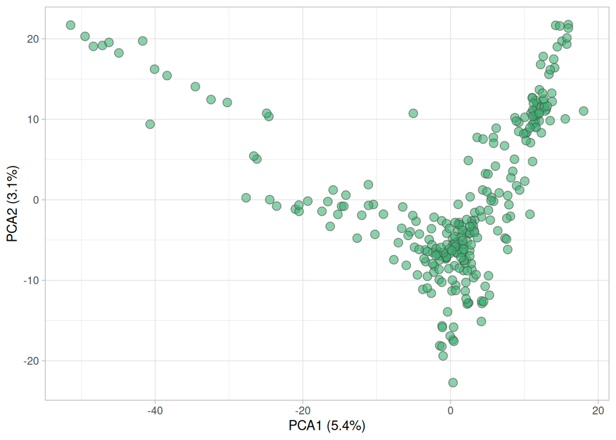

```r
ggplot(pc_data, aes(x = Dim.1, y = Dim.2)) +
  geom_point(shape = 21, size = 3, fill = 'mediumseagreen', colour = 'grey30', alpha = 0.6) +
  xlab(paste0("PCA1 (", round(pca$eig[1,2], 2), "%)")) +
  ylab(paste0("PCA2 (", round(pca$eig[2,2], 2), "%)")) +
  theme(axis.text.x = element_text(size = 10, family = "sans"),
        axis.text.y = element_text(size = 10, family = "sans")) +
  theme_light()
```

## 4.6 *ScreePlot*

Primeiramente é calculado a porcentagem que cada componente principal explica, mas apenas pegando os 10 primeiros componentes principais. Posteriormente é criado um data.frame com os 10 componentes principais e suas respectivas variâncias. Por fim, é plotado o gráfico.

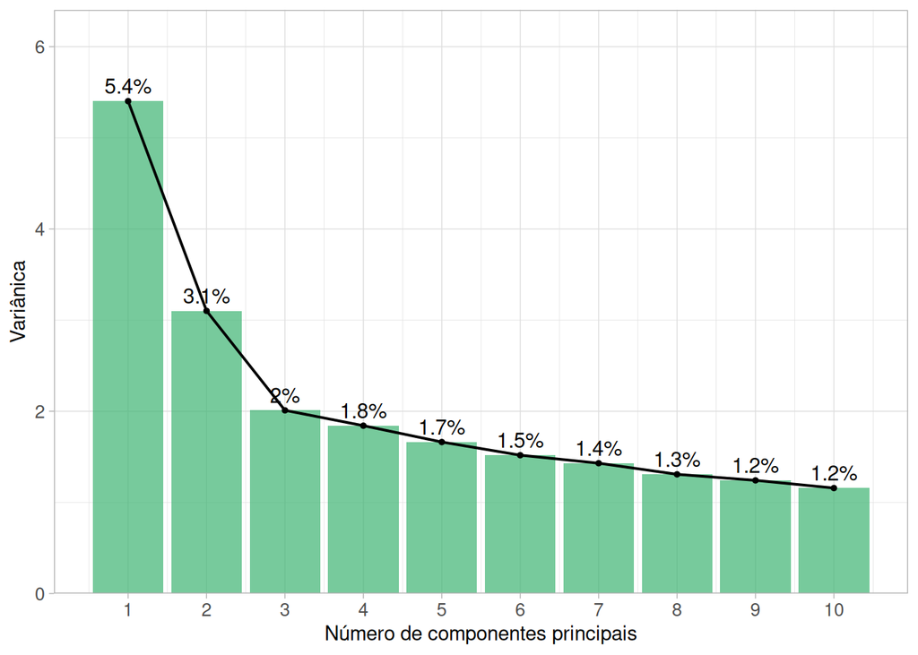

```r
var_explicada <- pca$eig[1:10,2]
dimensoes <- 1:10

scree_df <- data.frame(PC = dimensoes, Variance = var_explicada)

ggplot(scree_df, aes(x = PC, y = Variance)) +
  geom_bar(stat="identity",
           fill="mediumseagreen", alpha=0.7) +  # Barras
  geom_line(aes(group=1),
            color="black",
            size=0.7) +  # Linha conectando os pontos
  geom_point(color="black",
             size=1) +  # Pontos sobre a linha
  geom_text(aes(label = paste0(round(Variance,1), "%")),
            vjust = -0.5,
            size = 4) +  # Adicionando os valores da variância
  scale_x_continuous(breaks = 1:10) +  # Limitando o eixo X a 10 PCs
  scale_y_continuous(limits = c(0, max(var_explicada) + 1), expand = c(0, 0)) +
  xlab("Número de componentes principais") +
  ylab("Variânica") +
  theme_light() +
  theme(axis.text.x = element_text(size = 10, family = "sans"),
        axis.text.y = element_text(size = 10, family = "sans"))
```

# 5 Matriz de parentesco

Este código foi utilizado para estimar a matriz de parentesco genômico (G-matrix) a partir dos dados de marcadores SNPs, essa matriz representa o grau de similaridade genética entre os indivíduos com base nos marcadores.

```r
M <- scale(geno, center=TRUE, scale=FALSE)
K <- sum(apply(X=M, FUN=var, MARGIN=2))
G <- tcrossprod(M)/K
G[1:6, 1:6]
```

```
##               [,1]        [,2]         [,3]          [,4]         [,5]
## [1,]  0.9487442852  0.01679649  0.031394986 -0.0001998146  0.019465828
## [2,]  0.0167964911  0.99792636  0.011104436 -0.0036597697 -0.018777358
## [3,]  0.0313949861  0.01110444  1.012536833 -0.0137461478  0.009285613
## [4,] -0.0001998146 -0.00365977 -0.013746148  0.8040430926 -0.017821029
## [5,]  0.0194658276 -0.01877736  0.009285613 -0.0178210286  1.045902540
## [6,] -0.0319403607 -0.01520360 -0.029778138 -0.0568847803 -0.013656305
##             [,6]
## [1,] -0.03194036
## [2,] -0.01520360
## [3,] -0.02977814
## [4,] -0.05688478
## [5,] -0.01365630
## [6,]  1.02668212
```

```r
dim(G)
```

```
## [1] 281 281
```

## 5.1 *HeatMap*

Aqui é gerado um *HeatMap* (mapa de calor) para a matriz de parentesco genômico e salvado em um arquivo PDF. Agora, com o gráfico de PCA, *ScreePlot* e *HeatMap* temos material suficiente para discutir sobre a estrutura populacional da população utilizada no estudo de GWAS em questão. É sempre importante discutir relacionando com o histórico de melhoramento da cultura e tipo de reprodução (alógama, autógama ou mista) e comparando, sempre, com a literatura.

```r
pdf(file="G_relationship.pdf")
heatmap.2(G,
          col="heat.colors",
          revC=TRUE,
          trace='none',
          labRow='',
          labCol='',
          density.info='none',
          key=TRUE,
          key.title='VanRaden',
          key.xlab=' ',
          keysize=1.6)
dev.off()
```

# 6 Análise de GWAS para a altura da espiga no milho

## 6.1 EarHT (Altura de espiga)

Aqui selecionamos a coluna genótipo e o caráter altura de espiga na planilha do fenótipo.

```r
trait <- myY[,c(1,2)]
```

```r
myGN <- read.table("mdp_numeric.txt", header = TRUE)
colnames(myGN)[1] <- "Taxa"
head(myGN)
```

|  | Taxa | PZB00859.1 | PZA01271.1 | PZA03613.2 | PZA03613.1 | PZA03614.2 | PZA03614.1 | PZA00258.3 | PZA02962.13 | PZA02962.14 | PZA00599.25 | PZA02129.1 | PZA00393.1 | PZA02869.8 | PZA02869.4 | PZA02869.2 | PZA02032.1 | zagl1.5 | zagl1.2 | zagl1.6 | PZD00081.2 | zagl1.1 | PZB00919.1 | PZB00919.2 | PHM2244.142 | PZA03093.10 | PZA00181.5 | PZA00181.2 | PZA00528.1 | … |
| --- | --- | --- | --- | --- | --- | --- | --- | --- | --- | --- | --- | --- | --- | --- | --- | --- | --- | --- | --- | --- | --- | --- | --- | --- | --- | --- | --- | --- | --- | --- |
| 1 | 33-16 | 2 | 0 | 0 | 2 | 2 | 2 | 2 | 2 | 0 | 0 | 2 | 2 | 0 | 0 | 1 | 0 | 0 | 2 | 2 | 0 | 0 | 2 | 2 | 1 | 0 | 1 | 0 | 0 | … |
| 2 | 38-11 | 2 | 2 | 0 | 2 | 2 | 2 | 0 | 2 | 0 | 2 | 0 | 2 | 2 | 0 | 2 | 2 | 0 | 2 | 2 | 0 | 0 | 2 | 2 | 2 | 2 | 2 | 2 | 2 | … |
| 3 | 4226 | 2 | 0 | 0 | 2 | 2 | 2 | 0 | 2 | 0 | 0 | 0 | 2 | 0 | 0 | 2 | 0 | 0 | 2 | 2 | 0 | 0 | 2 | 2 | 2 | 2 | 0 | 0 | 0 | … |
| 4 | 4722 | 2 | 2 | 0 | 2 | 2 | 2 | 1 | 2 | 0 | 2 | 0 | 0 | 1 | 1 | 0 | 0 | 0 | 2 | 2 | 0 | 0 | 2 | 2 | 2 | 2 | 2 | 2 | 2 | … |
| 5 | A188 | 0 | 0 | 0 | 2 | 2 | 2 | 0 | 2 | 0 | 2 | 0 | 2 | 0 | 2 | 2 | 0 | 0 | 2 | 2 | 0 | 0 | 0 | 2 | 2 | 2 | 2 | 2 | 1 | … |
| 6 | A214N | 2 | 0 | 2 | 0 | 2 | 0 | 0 | 2 | 0 | 2 | 2 | 2 | 0 | 0 | 2 | 2 | 0 | 2 | 2 | 0 | 0 | 2 | 2 | 2 | 0 | 2 | 2 | 2 | … |

## 6.2 Modelos unilocus

### 6.2.1 GLM

O Modelo Linear Geral (GLM - *General Linear Model*) já representa um avanço nas análises de mapeamento por incorporar o efeito da estrutura populacional (matriz Q) como covariável. O GLM é também conhecido como modelo Q onde a matriz Q e os marcadores são considerados como efeitos fixos.

```r
if(!file.exists('./GLM')) dir.create('./GLM')
setwd('./GLM')
modelo_GLM <- GAPIT(Y=trait,
                    G =myG,
                    SNP.MAF = 0.05,
                    PCA.total = 2,
                    model = 'GLM')
```

### 6.2.2 MLM

O Modelo Linear Misto (MLM - *Mixed Linear Model*) além da matriz Q como efeito fixo também incorpora o grau de parentesco entre indivíduos (matriz K) como efeito aleatório, sendo também conhecido como modelo Q+K. Em geral, o modelo Q+K tem mostrado melhores resultados em comparação com o modelo Q.

```r
if(!file.exists('.MLM')) dir.create('./MLM')
setwd('./MLM')
myGAPIT <- GAPIT(Y=trait,
                 G=myG,
                 SNP.MAF = 0.05,
                 PCA.total=2,
                 model = 'MLM')
```

### 6.2.3 Avaliando a performace dos modelos unilocus

Agora vamos utilizar o gráfico de QQPLOT para análisar a performace e acurácia dos modelos. Para isso, pegamos as planilhas que contém os resultados de cada modelo e fazemos a leitura delas.

```r
GLM_data <- read.table(file = "GLM.csv",
                       header = TRUE,
                       sep = ",",
                       stringsAsFactors = FALSE)
MLM_data <- read.table(file = "MLM.csv",
                       header = TRUE,
                       sep = ",",
                       stringsAsFactors = FALSE)
head(GLM_data)
```

|  | SNP | Chromosome | Position | P.value | maf | nobs | Rsquare.of.Model.without.SNP | Rsquare.of.Model.with.SNP | FDR_Adjusted_P.values | effect |
| --- | --- | --- | --- | --- | --- | --- | --- | --- | --- | --- |
| 1 | PZD00032.1 | 10 | 30830484 | 2.684939e-07 | 0.47491039 | 279 | 0 | 0.10007769 | 0.0005014497 | 6.810215 |
| 2 | PZA03188.4 | 1 | 280719882 | 3.242481e-07 | 0.28315412 | 279 | 0 | 0.09863366 | 0.0005014497 | -7.957326 |
| 3 | PZB00801.1 | 1 | 174183331 | 5.736967e-07 | 0.34050179 | 279 | 0 | 0.09428234 | 0.0005914813 | 6.619306 |
| 4 | PZA03537.1 | 8 | 171581059 | 1.819956e-06 | 0.07168459 | 279 | 0 | 0.08555134 | 0.0013465201 | 11.647983 |
| 5 | PZA02811.5 | 6 | 146286305 | 2.176722e-06 | 0.41935484 | 279 | 0 | 0.08420644 | 0.0013465201 | 6.119024 |
| 6 | PZA00230.5 | 1 | 298412984 | 3.686468e-06 | 0.16129032 | 279 | 0 | 0.08026237 | 0.0017615317 | -8.021194 |

### 6.2.4 Alterando o nome da coluna P.value

O próximo passo é alterar o nome da coluna de “P.value” para apenas “P”.

```r
colnames(GLM_data)[colnames(GLM_data) == "P.value"] <- "P"
colnames(MLM_data)[colnames(MLM_data) == "P.value"] <- "P"
```

### 6.2.5 Adicionando uma coluna com a identificação do método

Neste momento, criamos uma coluna nova que contém o nome do respectivo método.

```r
GLM_data$Method <- "GLM"
MLM_data$Method <- "MLM"
```

### 6.2.6 Unificar as planilhas

Este chunck é utilizado para unir as planilhas e também tornar a coluna “P” como númerica.

```r
gwas_unilocus <- bind_rows(GLM_data, MLM_data)
gwas_unilocus$P <- as.numeric(gwas_unilocus$P)
```

### 6.2.7 QQ-Plot dos modelos unilocus

```r
geom_ribbon(aes(x = expected, ymin = clower, ymax = cupper),
            fill = "gray70", alpha = 0.2)
```

```
## mapping: x = ~expected, ymin = ~clower, ymax = ~cupper
## geom_ribbon: na.rm = FALSE, orientation = NA, lineend = butt, linejoin = round, linemitre = 10, outline.type = both
## stat_identity: na.rm = FALSE
## position_identity
```

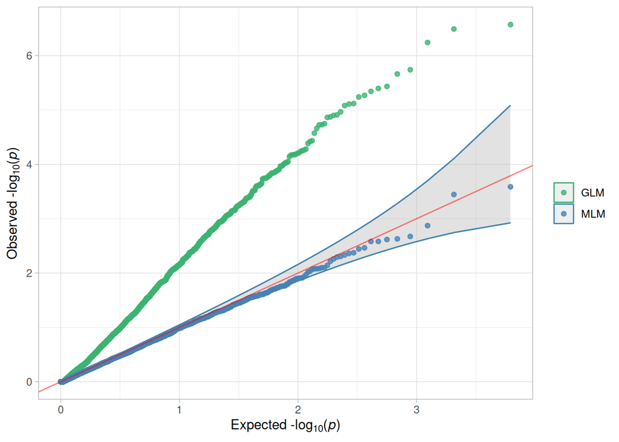

```r
gg_qqplot_multi <- function(df, ci = 0.95) {
  df <- df %>%
    group_by(Method) %>%
    mutate(
      observed = -log10(sort(P)),
      expected = -log10(ppoints(n())),
      clower = -log10(qbeta((1 - ci) / 2, shape1 = 1:n(), shape2 = n():1)),
      cupper = -log10(qbeta((1 + ci) / 2, shape1 = 1:n(), shape2 = n():1))
    ) %>%
    ungroup()

  log10Pe <- expression(paste("Expected -log"[10], "(",italic(p),")"))
  log10Po <- expression(paste("Observed -log"[10], "(",italic(p),")"))

  ggplot(df, aes(x = expected, y = observed, color = Method)) +
    geom_ribbon(aes(x = expected, ymin = clower, ymax = cupper),
                fill = "gray70", alpha = 0.2) +
    geom_point(size = 1.5, alpha = 0.8) +
    geom_abline(intercept = 0, slope = 1, color = "red", alpha = 0.5) +
    xlab(log10Pe) +
    ylab(log10Po) +
    theme_light() +
    theme(legend.title = element_blank()) +
    scale_color_manual(values = c(GLM = "mediumseagreen", MLM = "steelblue"))
}

qq_multi <- gg_qqplot_multi(gwas_unilocus)
qq_multi
```

## 6.3 Modelos multilocus

Atualmente, no GAPIT há disponível três modelos multilocus, sendo o FarmCPU (Fixed and Random Model Circulating Probability Unification), BLINK (Bayesian-information and Linkage-disequilibrium Iteratively Nested Keyway) e MLMM (Multiple Loci Mixed Model). Apenas para fins didáticos vamos demonstrar uma prática com o FarmCPU.

### 6.3.1 FarmCPU

O FarmCPU realiza uma primeira etapa em todo o genoma para detectar marcadores associados com a característica. Neste primeiro momento, não há controle para o parentesco entre indivíduos o que abre espaço para associações espúrias (erro tipo I), por isto, estes marcadores previamente significativos são chamados de pseudo-QTNs (Quantitative Trait Nucleotides) e podem estar associados a estrutura populacional ou grau de parentesco. Em seguida, uma nova etapa se inicia a partir destes pseudo-QTNs, sendo eles utilizados para estimar a matriz K, ocorrendo um ajuste para cada marcador individualmente, tendo um p.valor estimado no final da análise. Mais informações sobre o FarmCPU podem ser encontradas em Liu et al. (2016).

```r
if(!file.exists('./FarmCPU')) dir.create('./FarmCPU')
setwd('./FarmCPU')
myGAPIT_FarmCPU <- GAPIT(Y=trait,
                         G=myG,
                         model = 'FarmCPU')
```

### 6.3.2 Leitura dos resultados

```r
FarmCPU <- read.table('./FarmCPU/GAPIT.FarmCPU.EarHT.GWAS.Results.csv',
                      header = TRUE,
                      sep = ',')
FarmCPU
```

| SNP | Chromosome | Position | P.value | maf | nobs | Rsquare.of.Model.without.SNP | Rsquare.of.Model.with.SNP | FDR_Adjusted_P.values | effect |
| --- | --- | --- | --- | --- | --- | --- | --- | --- | --- |
| PZA03188.4 | 1 | 280719882 | 1.644503e-08 | 0.283154122 | 279 | NA | NA | 5.086448e-05 | -6.103345e+00 |
| PZA03647.3 | 3 | 185318086 | 1.807536e-06 | 0.288530466 | 279 | NA | NA | 2.795354e-03 | 4.675477e+00 |
| PZA03214.3 | 1 | 245136244 | 3.005908e-05 | 0.082437276 | 279 | NA | NA | 2.975422e-02 | -9.636614e+00 |
| PZA03559.1 | 2 | 15810363 | 3.847943e-05 | 0.426523297 | 279 | NA | NA | 2.975422e-02 | -3.452302e+00 |
| PZB00379.1 | 9 | 26661626 | 1.672216e-04 | 0.471326165 | 279 | NA | NA | 1.034433e-01 | 3.044479e+00 |
| PZA03320.3 | 5 | 190229872 | 2.110597e-04 | 0.326164875 | 279 | NA | NA | 1.088013e-01 | -3.287393e+00 |
| PZA03395.5 | 8 | 130388141 | 5.413891e-04 | 0.084229391 | 279 | NA | NA | 2.392167e-01 | 4.594428e+00 |
| PZB01881.10 | 6 | 93263605 | 7.159601e-04 | 0.043010753 | 279 | NA | NA | 2.482111e-01 | 6.306893e+00 |
| PZA03284.3 | 5 | 91651999 | 7.222436e-04 | 0.220430108 | 279 | NA | NA | 2.482111e-01 | -3.492385e+00 |
| PZA00944.2 | 1 | 91429158 | 1.335152e-03 | 0.123655914 | 279 | NA | NA | 4.087088e-01 | 4.500737e+00 |

[output cut: 3083 more lines]

### 6.3.3 Visualizando os SNPs significativos

```r
fdr <- data.frame(SNP = FarmCPU$SNP,
                  Chr = FarmCPU$Chromosome,
                  p_valor = FarmCPU$P.value,
                  FDR = p.adjust(FarmCPU$P.value, method = "fdr"),
Effect = FarmCPU$effect)
fdr<- fdr[order(fdr[,3]), ] # ordena os dados pela 3ª coluna do data frame.
fdr
```

|  | SNP | Chr | p_valor | FDR | Effect |
| --- | --- | --- | --- | --- | --- |
| 1 | PZA03188.4 | 1 | 1.644503e-08 | 5.086448e-05 | -6.103345e+00 |
| 2 | PZA03647.3 | 3 | 1.807536e-06 | 2.795354e-03 | 4.675477e+00 |
| 3 | PZA03214.3 | 1 | 3.005908e-05 | 2.975422e-02 | -9.636614e+00 |
| 4 | PZA03559.1 | 2 | 3.847943e-05 | 2.975422e-02 | -3.452302e+00 |
| 5 | PZB00379.1 | 9 | 1.672216e-04 | 1.034433e-01 | 3.044479e+00 |
| 6 | PZA03320.3 | 5 | 2.110597e-04 | 1.088013e-01 | -3.287393e+00 |
| 7 | PZA03395.5 | 8 | 5.413891e-04 | 2.392167e-01 | 4.594428e+00 |
| 8 | PZB01881.10 | 6 | 7.159601e-04 | 2.482111e-01 | 6.306893e+00 |
| 9 | PZA03284.3 | 5 | 7.222436e-04 | 2.482111e-01 | -3.492385e+00 |
| 10 | PZA00944.2 | 1 | 1.335152e-03 | 4.087088e-01 | 4.500737e+00 |

[output cut: 3083 more lines]

### 6.3.4 Selecionar SNPs significativos com FDR < 0.05

Esses quatro SNPs tiveram FDR < 0.05 São considerados associação significativa entre o marcador e o fenótipo analisado O valor Effect indica o tamanho e direção do efeito do SNP no fenótipo: Efeito negativo: reduz o valor do caráter Efeito positivo: aumenta

```r
snps_significativos <- fdr[fdr$FDR < 0.05, ]
nrow(snps_significativos)
```

```
## [1] 4
```

### 6.3.5 Limiar para o gráfico

Esse comando está fazendo um gráfico simples (scatterplot) entre: no eixo x: os p-valores dos SNPs significativos (FDR < 0.05) no eixo y: os FDR desses mesmos SNPs

Esse gráfico mostra como os p-valores se transformam em FDR após correção múltipla. Que os SNPs com p-valores muito pequenos continuam muito significativos (FDR baixo). Que alguns SNPs são apenas marginalmente significativos (FDR próximo de 0.05).

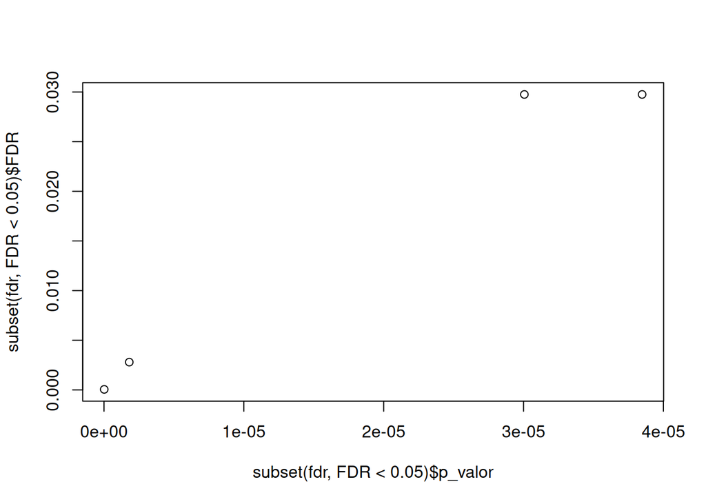

```r
plot(subset(fdr, FDR < 0.05)$p_valor, subset(fdr, FDR < 0.05)$FDR)
```

```r
summary(lm(subset(fdr, FDR < 0.05)$p_valor ~ subset(fdr, FDR < 0.05)$FDR))
```

```
##
## Call:
## lm(formula = subset(fdr, FDR < 0.05)$p_valor ~ subset(fdr, FDR <
##     0.05)$FDR)
##
## Residuals:
##          1          2          3          4
##  6.821e-07 -7.515e-07 -4.175e-06  4.245e-06
##
## Coefficients:
##                               Estimate Std. Error t value Pr(>|t|)
## (Intercept)                 -7.254e-07  3.171e-06  -0.229    0.840
## subset(fdr, FDR < 0.05)$FDR  1.175e-03  1.504e-04   7.812    0.016 *
## ---
## Signif. codes:  0 '***' 0.001 '**' 0.01 '*' 0.05 '.' 0.1 ' ' 1
##
## Residual standard error: 4.271e-06 on 2 degrees of freedom
## Multiple R-squared:  0.9683, Adjusted R-squared:  0.9524
## F-statistic: 61.03 on 1 and 2 DF,  p-value: 0.01599
```

Como o Manhattan plot usa p-valores no eixo Y, mas a significância é definida por FDR < 0.05, ajustamos um modelo linear usando os SNPs significativos para estimar qual p-valor corresponde exatamente ao FDR = 0.05. O resultado foi um p-valor de ~5.8×10⁻⁵, que utilizamos como linha de corte no gráfico. Assim, garantimos que o limiar visual no Manhattan representa corretamente o critério estatístico aplicado. Vale ressaltar que O FDR é calculado pelo método de Benjamini–Hochberg. Primeiro, os p-valores são ordenados do menor para o maior. Cada p-valor recebe um valor ajustado usando a fórmula (p × número de testes / ranking). Depois, os valores são corrigidos para garantir uma sequência crescente. O resultado final indica a probabilidade de que um SNP considerado significativo seja, na verdade, um falso positivo.

```r
fdr<- -7.254e-07 + 1.175e-03*0.05
fdr
```

```
## [1] 5.80246e-05
```

### 6.3.6 Manhattan plot

Esse comando prepara os dados para o Manhattan plot. Primeiro selecionamos apenas as quatro colunas essenciais (SNP, cromossomo, posição física e p-valor). Depois renomeamos essas colunas para os nomes padrão usados pelas funções de plotagem. Isso garante que o script reconheça corretamente cada informação necessária para gerar o gráfico.

```r
manhatan_plot<- FarmCPU[, c(1:4)]
colnames(manhatan_plot) = c('SNP', 'CHR', 'BP', 'P')
```

O código calcula a posição genômica cumulativa dos SNPs para construção do Manhattan plot. Primeiro, para cada cromossomo, identifica-se a maior posição (max_BP) e calcula-se um deslocamento acumulado (BP_add) que representa onde cada cromossomo deve começar no eixo contínuo. Em seguida, esse deslocamento é adicionado à posição original dos SNPs (BP) para gerar uma nova coluna (BP_cum), que permite plotar todos os cromossomos em sequência contínua no gráfico.

```r
data_cum <- manhatan_plot %>%
  group_by(CHR) %>%
  summarise(max_BP = max(BP)) %>%
  mutate(BP_add = lag(cumsum(max_BP), default = 0)) %>%
  select(CHR, BP_add)

manhatan_plot <- manhatan_plot %>%
  inner_join(data_cum, by = "CHR") %>%
  mutate(BP_cum = BP + BP_add)
```

O código calcula o ponto central de cada cromossomo no eixo cumulativo, permitindo posicionar corretamente os rótulos dos cromossomos no Manhattan plot

```r
axis_set <- manhatan_plot %>%
  group_by(CHR) %>%
  summarize(center = max(BP_cum)-(max(BP_cum)-min(BP_cum))/2)
```

Esse chunk cria um Manhattan plot com ggplot2, usando as posições cumulativas (BP_cum) no eixo X e -log10(P) no eixo Y, adicionando uma linha de corte (limiar), pontos coloridos por cromossomo, rótulos centrais para cada cromossomo e ajuste estético final.

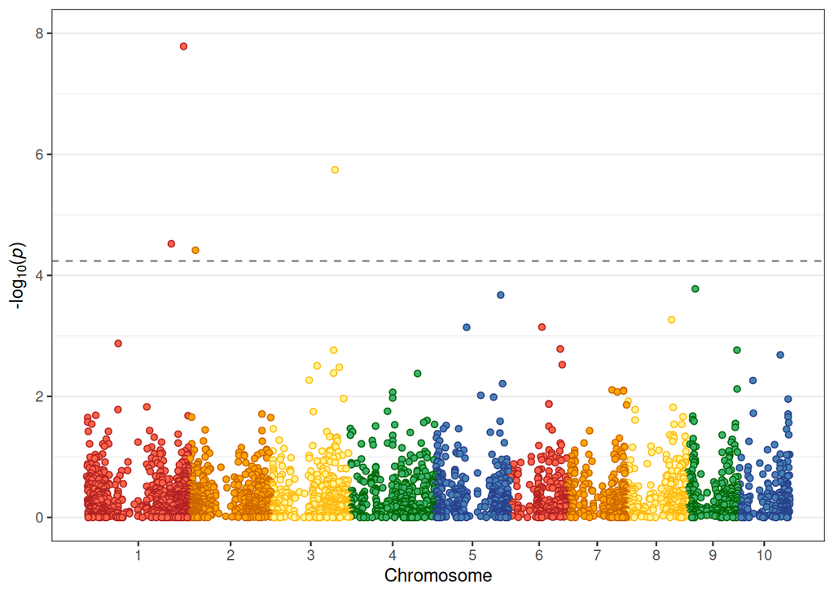

```r
manhatan <-
  ggplot(manhatan_plot,
         aes(x = BP_cum,
             y = -log10(P),
             group = as.factor(CHR))) +
  geom_hline(yintercept = -log10(fdr),
             color = "gray50", linetype = "dashed") +
  geom_point(aes(colour = as.factor(CHR),
                 fill = as.factor(CHR)), alpha = 1, size = 1.5, shape = 21) +
  scale_x_continuous(labels = axis_set$CHR, breaks = axis_set$center) +
  scale_colour_manual(values = rep(c("firebrick",
                                     "darkorange3",
                                     "darkgoldenrod1",
                                     "darkgreen",
                                     "royalblue4"),
                                   length(unique(axis_set$CHR)))) +
  scale_fill_manual(values = rep(c("tomato",
                                   "orange",
                                   "khaki1",
                                   "mediumseagreen",
                                   "steelblue"),
                                 length(unique(axis_set$CHR)))) +
  xlab("Chromosome") +
 scale_y_continuous(limits = c(0,8), breaks = seq(0,8,2)) +
  ylab(expression(paste("-log"[10], "(", italic(p), ")"))) +
  theme_bw() +
  theme(legend.position = "none",
        panel.grid.major.x = element_blank(),
        panel.grid.minor.x = element_blank())
manhatan
```

### 6.3.7 Salvar gráfico

```r
ggsave("manhatan_fdr.png",
       width = 6.5,
       height = 4.02,
       dpi = 300)
```

### 6.3.8 QQ Plot

Esse chunk cria uma função para gerar um QQ-plot dos valores-p do GWAS, comparando os valores observados com os valores esperados sob a hipótese nula (sem associações reais). Primeiro, a função organiza os p-values, calcula os valores esperados e constrói um intervalo de confiança usando a distribuição Beta (A distribuição Beta foi usada porque ela descreve o comportamento esperado dos p-valores após serem ordenados). Esses elementos formam uma banda cinza que indica a variação esperada dos pontos caso os p-values sigam uma distribuição uniforme.

- “function(ps, ci = 0.95)” ps - vetor de valores-p do GWAS e ci:intervalo de confiança.
- “length(ps)” - conta quantos valores-p existem. Isso é usado para calcular os quantis esperados e o intervalo de confiança.
- “observed = -log10(sort(ps))” - ordena os p-values do menor para o maior e converte para -log10.
- “expected = -log10(ppoints(n))” - gera valores esperados sob a hipótese nula de distribuição uniforme.
- “clower e cupper” - formam a faixa cinza do QQ plot (intervalo de confiança).
- “geom_ribbom” - cria uma banda cinza entre clower e cupper

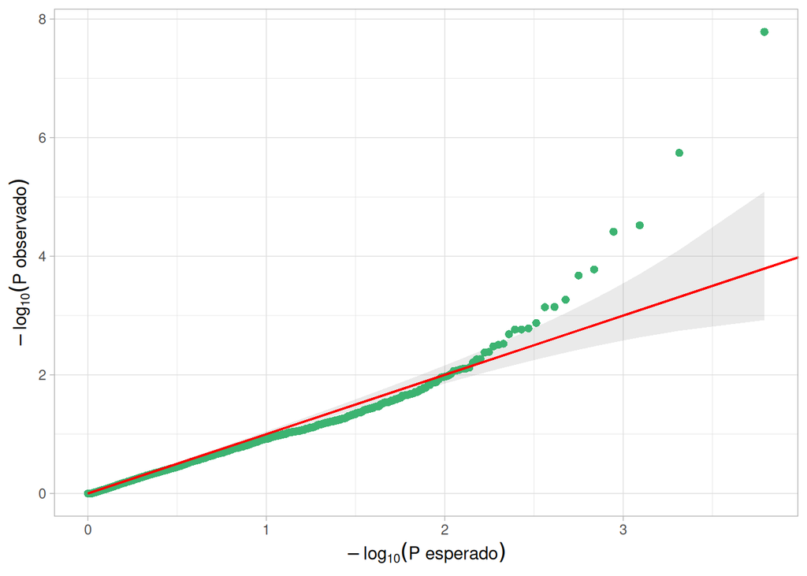

```r
gg_qqplot <- function(ps, ci = 0.95) {
  n  <- length(ps)
  df <- data.frame(
    observed = -log10(sort(ps)),
    expected = -log10(ppoints(n)),
    clower   = -log10(qbeta(p = (1 - ci) / 2, shape1 = 1:n, shape2 = n:1)),
    cupper   = -log10(qbeta(p = (1 + ci) / 2, shape1 = 1:n, shape2 = n:1))
  )
  log10Pe <- expression(paste("Expected -log"[10], "(",italic(p),")"))
  log10Po <- expression(paste("Observed -log"[10], "(",italic(p),")"))
  ggplot(df) +
    geom_ribbon( mapping = aes(x = expected, ymin = clower, ymax = cupper),
                 alpha = 0.1) +
    geom_point(aes(expected, observed),
               shape = 16,
               size =2,
               color = "mediumseagreen") +
    geom_segment(x=0, y=0, xend=5, yend=5, alpha = 0.5, color="red") +
xlab(expression(-log[10]("P esperado"))) +
ylab(expression(-log[10]("P observado")))
}
qqplot <-
  gg_qqplot(manhatan_plot$P)+
  theme_light()
qqplot
```

### 6.3.9 Salvar gráfico

```r
ggsave("qqplot_fdr.png",
       width = 6.5,
       height = 4.02,
       dpi = 300)
```

# 7 Recomendações

Sabe-se que os modelos multilocus possuem uma melhor capacidade de associação, por isso, a literatura vem testando estes modelos e estudando o seu desempenho e se há marcadores SNPs que se mantém significativos em diferentes modelos.

# 8 Agradecimentos

Agradecemos imensamente a Deus, por nos ter dado forças em todo o processo; ao nosso orientador prof. Dr. Alexandre Siqueira Guedes Coelho por todo conhecimento repassado; ao Dr. Renato Menezes e Renato Gomide pela ajuda na construção de todo o script.

# 9 Contato

- Dra. Luciana de Sousa Lopes: - lucianalopes@ufg.br
- Me. Cristian Cordeiro de Jesus - ccristian@discente.ufg.br

# 10 Referências

LIU, C.; HUANG, M.; FAN, B.; BUCKLER, E. S.; ZHANG, Z. Iterative Usage of Fixed and Random Effect Models for Powerful and Efficient Genome-Wide Association Studies. **PLoS Genetic**, v.12, n.2, p.1-24, 2016.

ZHU, C.; GORE, M.; BUCKLER, E. S.; YU, J. Status and Prospects of Association Mapping in Plants **The Plant Genome**, v.1, n.1, p.1-16, 2008.